# Tell me who you are and i’ll tell your position on the job market

- Show All Code
- Hide All Code
- View Source

Author

Varnel TIENTCHEU & Shella LANKOANDE

Published

April 22, 2026

```r
# Installation des packages
install.packages("haven")
install.packages("estimatr")
install.packages("tidyverse")
install.packages("fastDummies")
installed.packages("margins")
```

```
     Package LibPath Version Priority Depends Imports LinkingTo Suggests
     Enhances License License_is_FOSS License_restricts_use OS_type Archs
     MD5sum NeedsCompilation Built
```

```r
install.packages("corrplot")
install.packages("rstatix")
install.packages("modelsummary")
install.packages("plm")
install.packages("ggdag")
#-------------------------------------------------------------
library(haven)
library(plm)
library(rstatix)
library(estimatr)
library(tidyverse)
library(fastDummies)
library(modelsummary)
library(corrplot)
library(margins)
```

# I. Présentation du projet

Ce projet vise à mesurer l’effet de différentes variables individuelles sur la position sur le marché du travail, en particulier l’impact de l’origine des individus sur le salaire horaire et le chômage.

Les données proviennent d’un panel de 10 000 individus suivis sur 6 trimestres (2014-2016).

Les principales variables sont :

- **Marge intensive** : salaire net horaire (`salhoraire`, `logsalhoraire`)
- **Marge extensive** : statut sur le marché du travail (actif occupé, chômeur, inactif)
- **Variables individuelles** : âge, sexe, diplôme, CSP des parents, origine, indicatrices immigré/descendant, état de santé, situation matrimoniale…
- **Variables géographiques** : région, tranche d’unité urbaine , proportions de populations d’origines différentes…

L’objectif est de déterminer si l’origine affecte le salaire et l’accès à l’emploi, toutes choses égales par ailleurs.

Avant de passer à l’analyse économétrique, il est important de s’approprier la base de données et de comprendre les caractéristiques principales des individus suivis.

La base contient **10 000 individus** observés sur 6 trimestres (2014-2016). On dispose d’informations sur les caractéristiques individuelles (âge, sexe, diplôme, origine, état de santé, situation matrimoniale), les caractéristiques professionnelles (statut sur le marché du travail, salaire, heures travaillées, type de contrat) ainsi que sur l’environnement géographique (région, tranche d’unité urbaine, proportion de populations d’origines différentes).  
Cette étape est essentielle pour **s’assurer de la qualité des données**, guider le choix des variables explicatives et préparer l’analyse économétrique qui suit.

### 1) Chargement de la base de données

Nous commençons par importer la base de données fournie pour le projet.

Le code suivant permet de lire le fichier `.dta` et de vérifier ses dimensions (nombre de lignes et de colonnes) :

```r
df <- read_dta("DM_Subject_2_Data.dta")
dim(df)
```

```
[1] 60000    60
```

```r
df$salhoraire = df$salmensuel / (df$heuretra * 4.33)
```

### 2) Statistiques descriptives

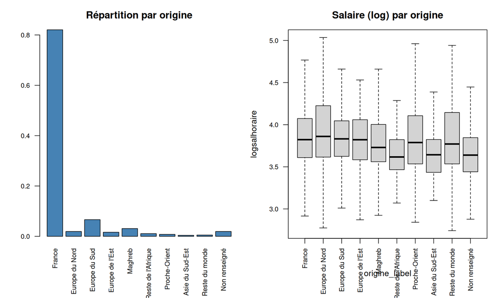

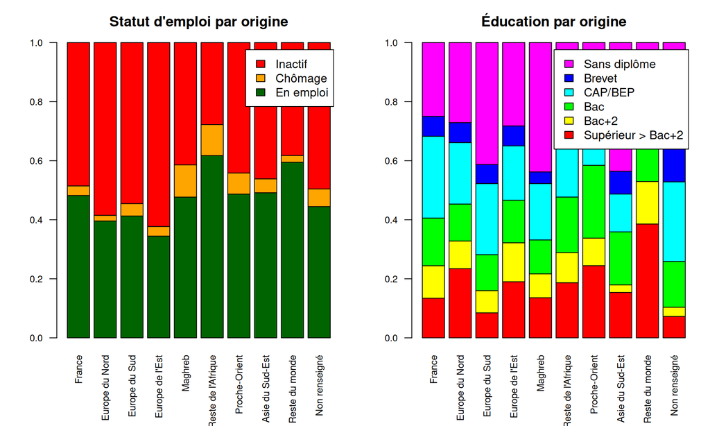

L’échantillon est massivement dominé par l’origine française (plus de 80 %). On observe une hétérogénéité marquée du capital humain : les populations originaires du Maghreb et Asie du Sud-Est présentent une part importante de non-diplômés, tandis que les origines d’Europe du Nord ou du Reste du monde affichent des taux de diplômes supérieurs élevés. Cette stratification éducative initiale confirme que le diplôme est un canal de transmission majeur des inégalités salariales qu’il faudra isoler.

Sur le marché du travail, les disparités sont visibles dès l’accès à l’emploi (marge extensive) : les origines africaines et maghrébines affichent des parts de chômage plus prononcées que la moyenne. Côté salaires (marge intensive), si les médianes des logs-salaires semblent globalement alignées, on distingue un tassement vers le bas pour le Reste de l’Afrique et l’Asie du Sud-Est. La forte dispersion dans tous les groupes, couplée à ces différences de médianes malgré des profils éducatifs parfois élevés, justifie la problématique de recherche d’un effet direct de l’origine au-delà des seules caractéristiques productives.

# II. Marge Intensive

Dans un premier temps, on étudie le salaire des actifs occupés et on s’intéresse à l’existence de potentielles inégalités salariales dues à l’origine. Le salaire n’est disponible qu’au premier et au dernier trimestre : données de panel avec T = 2 pour cette variable.

### Question 1 – Effet de l’origine sur le salaire horaire

Dans cette première partie, on s’intéresse à l’existence d’éventuelles inégalités salariales liées à l’origine des individus. Conformément à l’énoncé, on se restreint aux individus **actifs occupés** et on utilise uniquement **le dernier trimestre observé**, ce qui revient à travailler sur une coupe transversale des données.

#### **a) Modèle et choix de variables**

Afin d’identifier un effet causal, il est nécessaire de:

1. Inclure tous les **cofounders** (variables correlées à la fois à l’origine et au salaire);
2. Inclure toutes les variables correlées uniquement au salaire;
3. Ne pas inclure les variables à mi-chemin entre **Origine** et **salaire** pour éviter un biais de variable incluse.

Ceci nous conduit donc à retenir:

- **L’Origine**: c’est le coeur de l’étude; la variable dont on cherche l’effet sur le salaire;
- **L’âge** et $**l’âge^2**$: c’est un proxy de l’ancienneté.On l’inclut comme proxy de l’expérience professionnelle;
- **Le sexe**: pour capter les inégalités de salaire pourvant exister entre hommes et femmes;
- **La région** et la **tranche d’unité urbaine**: pour contrôler les spécificités du marché du travail local, et neutraliser l’effet de concentration des immigrés dans certaines villes où les salaires sont élevés;
- **L’éducation**: car le niveau de diplôme influence fortement le salaire, et ne pas l’inclure produirait un biais.

Dans la même logique, on choisit de ne pas contrôler les variables comme la catégorie socioprofessionnelle (CSP), et le type de contrat. En effet, si jamais il y’a de la discrimination à l’embauche du fait de l’origine, contrôler par ces variables reviendrait à neutraliser une partie de l’effet de l’origine sur le salaire.

Par ailleurs, il est tout à fait possible que l’éducation soit un canal par lequel l’origine influence le salaire; mais pour l’instant on choisit d’ignorer cela car ce sera abordé dans les questions suivantes.

Le DAG (Directed Acyclic Graph) suivant résume notre schéma de modélisation:

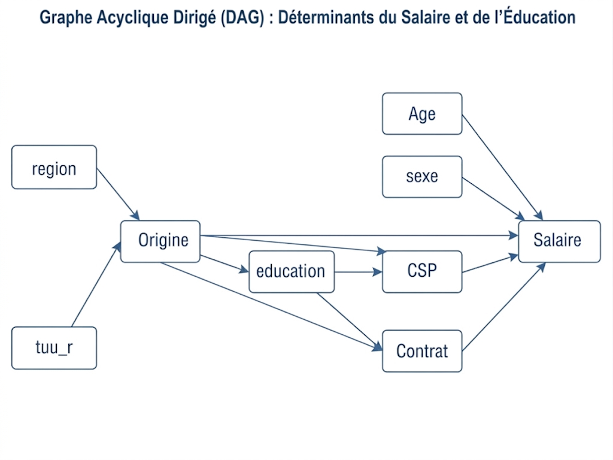

#### **b) Interprétation**

Tous les modèles estimés ne peuvent s’interpréter qu’en termes de prédiction et non de causalité. En effet, l’hypothèse d’abscence de biais de sélection est très peu crédible; bien qu’on ait contrôlé par certaines variables pertinentes.

Les interprétations suivantes, se feront (pour des besoins de simplicité) uniquement sur les personnes originaires d’afrique.

On va entraîner les deux modèles, mais de façon progressive en ajoutant des nouvelles variables au fur et à mesure, et voir comment les coefficients évoluent.

```r
#--------------------QUESTION 1--------------------------------
df1 <- df %>%
  filter(t == 6, acteu == 1)%>%
  mutate(
    age2  = age^2
  ) %>%
  droplevels()


regression <- function(y, data = df1){

  # On convertit l'argument en caractère
  y <- deparse(substitute(y))

  # Définition des listes de variables explicatives
  rhs1 <- "origine"
  rhs2 <- c(rhs1, "age", "age2", "homme")
  rhs3 <- c(rhs2, "region", "tuu_r")
  rhs4 <- c(rhs3, "education")
  rhs5 <- c(rhs4, "csp_actif", "contrat")

  # Estimation des modèles
  m1 <- lm_robust(reformulate(rhs1, y), data = data)
  m2 <- lm_robust(reformulate(rhs2, y), data = data)
  m3 <- lm_robust(reformulate(rhs3, y), data = data)
  m4 <- lm_robust(reformulate(rhs4, y), data = data)
  m5 <- lm_robust(reformulate(rhs5, y), data = data)

  # On regroupe pour le tableau
  models <- list(
    "modèle(1)" = m1,
    "modèle(2)" = m2,
    "modèle(3)" = m3,
    "modèle(4)" = m4,
    "modèle(5)" = m5
  )

  # Rendu du tableau
  modelsummary(
    models,
    stars = TRUE,
    coef_omit = "Intercept",
    gof_omit = "AIC|BIC|Log.Lik|F|Std.Errors",
    title = paste("Analyse de la variable :", y),
    notes = "Écarts-types robustes (HC2)."
  )

}
  # a) Modèle LOG
regression(logsalhoraire)
```

Analyse de la variable : logsalhoraire

|  | modèle(1) | modèle(2) | modèle(3) | modèle(4) | modèle(5) |
| --- | --- | --- | --- | --- | --- |
| origine03 | 0.120* | 0.123* | 0.121* | 0.078+ | 0.105* |
|  | (0.052) | (0.050) | (0.050) | (0.044) | (0.043) |
| origine04 | -0.004 | -0.007 | -0.028 | 0.036 | 0.051* |
|  | (0.026) | (0.025) | (0.026) | (0.024) | (0.023) |
| origine05 | -0.023 | -0.038 | -0.054 | -0.097+ | -0.026 |
|  | (0.056) | (0.052) | (0.052) | (0.053) | (0.045) |
| origine06 | -0.041 | -0.050+ | -0.104** | -0.039 | -0.009 |
|  | (0.031) | (0.030) | (0.032) | (0.029) | (0.024) |
| origine07 | -0.178*** | -0.153*** | -0.222*** | -0.155** | -0.067+ |
|  | (0.048) | (0.046) | (0.045) | (0.048) | (0.041) |
| origine08 | 0.095 | 0.104 | 0.051 | 0.081 | 0.090 |
|  | (0.083) | (0.078) | (0.076) | (0.062) | (0.062) |
| origine09 | -0.184* | -0.155* | -0.169* | -0.054 | -0.040 |
|  | (0.079) | (0.071) | (0.078) | (0.064) | (0.057) |
| origine10 | -0.010 | -0.001 | -0.028 | -0.083 | -0.045 |
|  | (0.099) | (0.096) | (0.101) | (0.080) | (0.075) |
| origine99 | -0.140** | -0.134** | -0.154*** | -0.070+ | -0.046 |
|  | (0.046) | (0.044) | (0.043) | (0.039) | (0.036) |
| age |  | 0.028*** | 0.029*** | 0.027*** | 0.016** |
|  |  | (0.006) | (0.006) | (0.006) | (0.006) |
| age2 |  | -0.000*** | -0.000*** | -0.000** | -0.000+ |
|  |  | (0.000) | (0.000) | (0.000) | (0.000) |
| homme |  | 0.134*** | 0.136*** | 0.164*** | 0.101*** |
|  |  | (0.012) | (0.012) | (0.011) | (0.011) |
| region |  |  | -0.004+ | -0.000 | -0.001 |
|  |  |  | (0.002) | (0.002) | (0.002) |
| tuu_r2 |  |  | -0.033+ | -0.030+ | -0.028+ |
|  |  |  | (0.017) | (0.016) | (0.015) |
| tuu_r3 |  |  | 0.015 | -0.002 | 0.002 |
|  |  |  | (0.018) | (0.016) | (0.015) |
| tuu_r4 |  |  | 0.059*** | 0.004 | -0.010 |
|  |  |  | (0.017) | (0.016) | (0.015) |
| tuu_r5 |  |  | 0.150*** | 0.095*** | 0.046* |
|  |  |  | (0.025) | (0.022) | (0.021) |
| education3 |  |  |  | -0.135*** | -0.032+ |
|  |  |  |  | (0.019) | (0.018) |
| education4 |  |  |  | -0.264*** | -0.087*** |
|  |  |  |  | (0.019) | (0.019) |
| education5 |  |  |  | -0.391*** | -0.147*** |
|  |  |  |  | (0.017) | (0.020) |
| education6 |  |  |  | -0.406*** | -0.157*** |
|  |  |  |  | (0.027) | (0.027) |
| education7 |  |  |  | -0.515*** | -0.240*** |
|  |  |  |  | (0.022) | (0.025) |
| csp_actif3 |  |  |  |  | 0.928 |
|  |  |  |  |  | (0.820) |
| csp_actif4 |  |  |  |  | 0.710 |
|  |  |  |  |  | (0.820) |
| csp_actif5 |  |  |  |  | 0.501 |
|  |  |  |  |  | (0.820) |
| csp_actif6 |  |  |  |  | 0.558 |
|  |  |  |  |  | (0.820) |
| contrat0 |  |  |  |  | -0.019 |
|  |  |  |  |  | (0.124) |
| contrat1 |  |  |  |  | -0.083 |
|  |  |  |  |  | (0.124) |
| contrat2 |  |  |  |  | -0.249+ |
|  |  |  |  |  | (0.127) |
| contrat3 |  |  |  |  | -0.261+ |
|  |  |  |  |  | (0.148) |
| contrat4 |  |  |  |  | -0.118 |
|  |  |  |  |  | (0.133) |
| contrat5 |  |  |  |  | -0.482** |
|  |  |  |  |  | (0.184) |
| Num.Obs. | 4046 | 4046 | 4046 | 4046 | 4046 |
| R2 | 0.008 | 0.062 | 0.083 | 0.251 | 0.361 |
| R2 Adj. | 0.006 | 0.059 | 0.079 | 0.247 | 0.356 |
| RMSE | 0.40 | 0.39 | 0.38 | 0.35 | 0.32 |

+ p < 0.1, * p < 0.05, ** p < 0.01, *** p < 0.001  
Écarts-types robustes (HC2).

```r
# a) Modèle en niveau
regression(salhoraire)
```

Analyse de la variable : salhoraire

|  | modèle(1) | modèle(2) | modèle(3) | modèle(4) | modèle(5) |
| --- | --- | --- | --- | --- | --- |
| origine03 | 1.464+ | 1.460* | 1.429+ | 0.798 | 1.083 |
|  | (0.757) | (0.742) | (0.730) | (0.659) | (0.674) |
| origine04 | 0.055 | 0.056 | -0.237 | 0.546 | 0.724 |
|  | (0.583) | (0.589) | (0.605) | (0.585) | (0.578) |
| origine05 | -0.304 | -0.562 | -0.777 | -1.313* | -0.424 |
|  | (0.730) | (0.654) | (0.642) | (0.664) | (0.574) |
| origine06 | -0.752+ | -0.835* | -1.564*** | -0.804* | -0.451 |
|  | (0.398) | (0.398) | (0.431) | (0.397) | (0.333) |
| origine07 | -1.940** | -1.645* | -2.558*** | -1.782** | -0.797 |
|  | (0.688) | (0.662) | (0.647) | (0.667) | (0.564) |
| origine08 | 1.607 | 1.887 | 1.179 | 1.429 | 1.469 |
|  | (1.428) | (1.378) | (1.340) | (1.154) | (1.135) |
| origine09 | -2.303** | -1.974** | -2.223** | -0.900 | -0.722 |
|  | (0.807) | (0.734) | (0.838) | (0.631) | (0.590) |
| origine10 | 0.342 | 0.560 | 0.206 | -0.624 | -0.227 |
|  | (1.329) | (1.305) | (1.367) | (1.124) | (1.028) |
| origine99 | -1.579** | -1.576** | -1.822*** | -0.787+ | -0.539 |
|  | (0.521) | (0.496) | (0.477) | (0.419) | (0.375) |
| age |  | 0.068 | 0.084 | 0.073 | -0.046 |
|  |  | (0.149) | (0.151) | (0.148) | (0.154) |
| age2 |  | 0.000 | 0.000 | 0.001 | 0.001 |
|  |  | (0.002) | (0.002) | (0.002) | (0.002) |
| homme |  | 1.592*** | 1.608*** | 1.964*** | 1.260*** |
|  |  | (0.173) | (0.172) | (0.163) | (0.161) |
| region |  |  | -0.061* | -0.020 | -0.026 |
|  |  |  | (0.028) | (0.026) | (0.025) |
| tuu_r2 |  |  | -0.330 | -0.295 | -0.280 |
|  |  |  | (0.249) | (0.236) | (0.228) |
| tuu_r3 |  |  | 0.084 | -0.141 | -0.085 |
|  |  |  | (0.237) | (0.219) | (0.207) |
| tuu_r4 |  |  | 0.877*** | 0.131 | -0.082 |
|  |  |  | (0.254) | (0.236) | (0.227) |
| tuu_r5 |  |  | 1.993*** | 1.232*** | 0.602+ |
|  |  |  | (0.386) | (0.352) | (0.338) |
| education3 |  |  |  | -2.210*** | -0.803** |
|  |  |  |  | (0.311) | (0.293) |
| education4 |  |  |  | -3.794*** | -1.543*** |
|  |  |  |  | (0.284) | (0.285) |
| education5 |  |  |  | -5.376*** | -2.318*** |
|  |  |  |  | (0.259) | (0.280) |
| education6 |  |  |  | -5.588*** | -2.524*** |
|  |  |  |  | (0.387) | (0.391) |
| education7 |  |  |  | -6.367*** | -2.948*** |
|  |  |  |  | (0.332) | (0.352) |
| csp_actif3 |  |  |  |  | 7.601 |
|  |  |  |  |  | (5.814) |
| csp_actif4 |  |  |  |  | 4.236 |
|  |  |  |  |  | (5.809) |
| csp_actif5 |  |  |  |  | 2.138 |
|  |  |  |  |  | (5.808) |
| csp_actif6 |  |  |  |  | 2.545 |
|  |  |  |  |  | (5.812) |
| contrat0 |  |  |  |  | -1.935 |
|  |  |  |  |  | (2.982) |
| contrat1 |  |  |  |  | -2.496 |
|  |  |  |  |  | (2.994) |
| contrat2 |  |  |  |  | -4.138 |
|  |  |  |  |  | (3.043) |
| contrat3 |  |  |  |  | -4.107 |
|  |  |  |  |  | (3.104) |
| contrat4 |  |  |  |  | -2.700 |
|  |  |  |  |  | (3.046) |
| contrat5 |  |  |  |  | -6.230+ |
|  |  |  |  |  | (3.385) |
| Num.Obs. | 4046 | 4046 | 4046 | 4046 | 4046 |
| R2 | 0.006 | 0.046 | 0.065 | 0.200 | 0.279 |
| R2 Adj. | 0.004 | 0.043 | 0.061 | 0.196 | 0.273 |
| RMSE | 5.71 | 5.59 | 5.54 | 5.12 | 4.86 |

+ p < 0.1, * p < 0.05, ** p < 0.01, *** p < 0.001  
Écarts-types robustes (HC2).

Toutes choses égales par ailleurs, le modèle 1 prédit qu’un individu originaire d’Afrique gagne en moyenne **1,94 $/h de moins** qu’un Français (soit une pénalité de **17,8 %** selon la spécification en log). Ce résultat est statistiquement significatif au seuil de **1 %**. L’ajout des variables de contrôle (âge, sexe et zone géographique) affine l’estimation, mais le signe, l’ampleur et la significativité de l’effet demeurent **robustes**.

En contrôlant en plus par l’**éducation** (modèle 4), l’écart se réduit légèrement mais reste massif : un individu originaire d’Afrique gagne désormais, toutes choses égales par ailleurs, **1,78 $/h de moins** qu’un Français (soit **15 %** en moins dans le modèle en log). La persistance de cet effet, même à diplôme identique, suggère qu’une part prépondérante de l’inégalité salariale est directe et ne s’explique pas uniquement par des différences de capital humain. L’ajout de **éducation** provoque en plus une hausse substantielle du $R^2$ (passant de **8,3%** à **25,1%**). Cette progression démontre que le capital humain est le principal facteur explicatif de la variance des salaires dans notre échantillon.

Enfin, le modèle 5 intègre la CSP et le type de contrat. L’effet de l’origine devient beaucoup plus fragile. Le coefficient n’est plus significatif dans le modèle en niveau et ne l’est qu’au seuil de **10 %** dans le modèle en log. Ce résultat suggère qu’à CSP et type de contrat identiques, l’écart de salaire horaire tend à s’estomper statistiquement. En d’autres termes, l’essentiel du désavantage lié à l’origine constaté dans les modèles précédents semble transiter par une **ségrégation professionnelle** (accès plus difficile aux postes qualifiés et aux contrats stables) plutôt que par une inégalité de rémunération directe au sein d’un même poste.

#### **c) Canaux de transmission de l’effet de l’origine sur le salaire**

Les régressions précédentes met en évidence une pénalité de 17,8% pour les individus d’origine africaine par rapport aux français (modèle 1). L’introduction du niveau d’éducation (modèle 4), ne réduit cet écart qu’à 15,5%; ce qui suggère que la disparité salariale ne résulte pas principalement d’une différence de capital humain. L’éducation, bien que élément important du salaire, n’explique qu’une faible part de l’inégalité liée à l’origine.

En ajoutant la CSP et le type de contrat (modèle 5), on observe un effondrement de l’amplitude des coefficients de l’éducation, et une chute de la pénalité à 6,7%. Cela prouve qu’une grande partie du rendement de l’éducation transite par le canal de **l’insertion professionnelle**. La CSP et le contrat absorbent donc une partie de l’effet de l’éducation (et de l’origine).

Finalement, ces résultats révèlent 02 possibles formes de discrimination. D’une part, **une discrimination à l’embauche (prépondérante):** l’origine impacterait l’obtention de statuts particuliers (cadres) ou de contrats stables (CDI). D’autre part, **une discrimination à la rémunération (pure)**, qui subsiste même à poste et contrat identiques.

### Question 2 – Inclure le niveau de diplôme comme variable de contrôle

#### **a) Problème qui peut survenir en contrôlant par le niveau de diplôme**

Dans cette partie, on s’intéresse à l’effet de l’origine sur le salaire. Si la réalité est telle que l’origine influence le salaire à travers le niveau d’éducation, alors en contrôlant par l’éducation, on commet un **biais de variable incluse** puisqu’on bloque un chemin causal. Par conséquent, le coefficient de Origine est biaisé vers le bas, et ne mesure que l’effet “**à niveau d’éducation égal**”.

De plus, l’éducation est certainement endogène ici, car il n’est certainement pas choisi au hasard par les individus (actifs occupés) de notre échantillon. Il est donc correlé aux facteurs inobservés.

#### **b) Variables disponibles pour instrumenter l’éducation**

Comme instruments, on peut utiliser: la catégorie socio-professionnelle des parents.

- Pertinence: La CSP des parents devrait être correlée au niveau d’éducation de l’enfant, notamment en raison de l’héritage culturel et/ou la reproduction sociale. Un enfant ayant des parents qui sont professeurs d’université par exemple, aura tendance à poursuivre ses études jusqu’au master au moins (ou Doctorat), contrairement à un enfant d’ouvriers.
- Exogénéité: Elle repose sur une hypothèse qui est discutable: l*a profession des parents n’influence le salaire de l’enfant que par le niveau diplôme*. En pratique, les enfants peuvent très biens bénéficier des “connexions” ou du “réseau” de leurs parents pour décrocher des emplois bien rémunérés.

  ```r
  #--------------------QUESTION 2-----------------------------

            #--------Pertinence----------
  m_iv <- iv_robust(
    logsalhoraire ~ origine + age + age2 + homme + region + tuu_r + education |
      origine + age + age2 + homme + region + tuu_r + csp_mere,
    data = df1,
    diagnostics = TRUE # TRÈS IMPORTANT pour avoir le F-test
  )

  summary(m_iv)
  ```

  ```
  Call:
  iv_robust(formula = logsalhoraire ~ origine + age + age2 + homme +
      region + tuu_r + education | origine + age + age2 + homme +
      region + tuu_r + csp_mere, data = df1, diagnostics = TRUE)

  Standard error type:  HC2

  Coefficients:
                Estimate Std. Error t value  Pr(>|t|)   CI Lower   CI Upper   DF
  (Intercept)  3.1947186  1.745e-01 18.3111 5.269e-72  2.8526634  3.537e+00 4023
  origine03    0.0769272  4.860e-02  1.5828 1.135e-01 -0.0183603  1.722e-01 4023
  origine04    0.0532342  3.351e-02  1.5887 1.122e-01 -0.0124590  1.189e-01 4023
  origine05   -0.0971312  5.949e-02 -1.6326 1.026e-01 -0.2137734  1.951e-02 4023
  origine06   -0.0053161  3.659e-02 -0.1453 8.845e-01 -0.0770596  6.643e-02 4023
  origine07   -0.1435007  6.209e-02 -2.3111 2.088e-02 -0.2652342 -2.177e-02 4023
  origine08    0.1033593  7.841e-02  1.3182 1.875e-01 -0.0503720  2.571e-01 4023
  origine09   -0.0174043  9.731e-02 -0.1789 8.581e-01 -0.2081770  1.734e-01 4023
  origine10   -0.0848880  8.911e-02 -0.9526 3.408e-01 -0.2595944  8.982e-02 4023
  origine99   -0.0713317  5.421e-02 -1.3159 1.883e-01 -0.1776061  3.494e-02 4023
  age          0.0296382  7.852e-03  3.7747 1.625e-04  0.0142442  4.503e-02 4023
  age2        -0.0002161  8.987e-05 -2.4049 1.622e-02 -0.0003923 -3.993e-05 4023
  homme        0.1781293  1.583e-02 11.2528 6.050e-29  0.1470940  2.092e-01 4023
  region       0.0007926  2.287e-03  0.3465 7.290e-01 -0.0036920  5.277e-03 4023
  tuu_r2      -0.0359253  1.823e-02 -1.9702 4.888e-02 -0.0716745 -1.762e-04 4023
  tuu_r3      -0.0057549  1.837e-02 -0.3133 7.541e-01 -0.0417671  3.026e-02 4023
  tuu_r4      -0.0117801  1.847e-02 -0.6377 5.237e-01 -0.0479948  2.443e-02 4023
  tuu_r5       0.0814329  2.835e-02  2.8725 4.094e-03  0.0258531  1.370e-01 4023
  education3  -0.1766843  1.724e-01 -1.0248 3.055e-01 -0.5146937  1.613e-01 4023
  education4  -0.1980281  1.677e-01 -1.1809 2.377e-01 -0.5267982  1.307e-01 4023
  education5  -0.5245113  1.143e-01 -4.5894 4.580e-06 -0.7485774 -3.004e-01 4023
  education6  -0.1725488  2.899e-01 -0.5953 5.517e-01 -0.7408197  3.957e-01 4023
  education7  -0.7114559  1.375e-01 -5.1727 2.420e-07 -0.9811112 -4.418e-01 4023

  Multiple R-squared:  0.1797 ,   Adjusted R-squared:  0.1752
  F-statistic: 24.02 on 22 and 4023 DF,  p-value: < 2.2e-16

  Diagnostics:
                                numdf dendf  value p.value
  Weak instruments (education3)    31  3997 10.555  <2e-16 ***
  Weak instruments (education4)    31  3997  9.941  <2e-16 ***
  Weak instruments (education5)    31  3997 12.457  <2e-16 ***
  Weak instruments (education6)    31  3997  5.550  <2e-16 ***
  Weak instruments (education7)    31  3997  9.497  <2e-16 ***
  Wu-Hausman                        5  4018  1.790  0.1114
  Overidentifying                  26    NA 35.747  0.0964 .
  ---
  Signif. codes:  0 '***' 0.001 '**' 0.01 '*' 0.05 '.' 0.1 ' ' 1
  ```

Les tests de diagnostic indiquent que nos instruments (CSP de la mère) sont globalement **pertinents**. Pour la plupart des niveaux d’éducation, la statistique F est proche ou supérieure à **10**, ce qui correspond à la règle empirique usuelle pour écarter le risque d’instruments faibles. On note toutefois une faiblesse relative pour le niveau `education6` ($F = 5,55$). Néanmoins, les p-valeurs extrêmement faibles ($< 2e-16$) sur l’ensemble des modalités confirment que la CSP des parents reste un prédicteur significatif du parcours scolaire, permettant ainsi une identification du modèle.

#### **b) Interprétation des résultats**

```r
        #-------Estimation------------
m_ols <- lm(logsalhoraire ~ origine + age + age2 + homme + region + tuu_r + education, data = df1)
models_iv <- list(
  "Modèle 4" = m_ols, # le modèle précédent
  "IV (2SLS)" = m_iv
)

modelsummary(
  models_iv,
  stars = TRUE,
  coef_omit = "Intercept",
  gof_omit = "AIC|BIC|Log.Lik|F|Std.Errors",
  title = "Comparaison MCO vs Variables Instrumentales",
  notes = "Instruments : CSP de la mere."
)
```

Comparaison MCO vs Variables Instrumentales

|  | Modèle 4 | IV (2SLS) |
| --- | --- | --- |
| origine03 | 0.078+ | 0.077 |
|  | (0.046) | (0.049) |
| origine04 | 0.036 | 0.053 |
|  | (0.024) | (0.034) |
| origine05 | -0.097+ | -0.097 |
|  | (0.049) | (0.059) |
| origine06 | -0.039 | -0.005 |
|  | (0.032) | (0.037) |
| origine07 | -0.155*** | -0.144* |
|  | (0.046) | (0.062) |
| origine08 | 0.081 | 0.103 |
|  | (0.064) | (0.078) |
| origine09 | -0.054 | -0.017 |
|  | (0.085) | (0.097) |
| origine10 | -0.083 | -0.085 |
|  | (0.070) | (0.089) |
| origine99 | -0.070+ | -0.071 |
|  | (0.040) | (0.054) |
| age | 0.027*** | 0.030*** |
|  | (0.004) | (0.008) |
| age2 | -0.000*** | -0.000* |
|  | (0.000) | (0.000) |
| homme | 0.164*** | 0.178*** |
|  | (0.011) | (0.016) |
| region | -0.000 | 0.001 |
|  | (0.002) | (0.002) |
| tuu_r2 | -0.030+ | -0.036* |
|  | (0.016) | (0.018) |
| tuu_r3 | -0.002 | -0.006 |
|  | (0.017) | (0.018) |
| tuu_r4 | 0.004 | -0.012 |
|  | (0.015) | (0.018) |
| tuu_r5 | 0.095*** | 0.081** |
|  | (0.022) | (0.028) |
| education3 | -0.135*** | -0.177 |
|  | (0.018) | (0.172) |
| education4 | -0.264*** | -0.198 |
|  | (0.018) | (0.168) |
| education5 | -0.391*** | -0.525*** |
|  | (0.017) | (0.114) |
| education6 | -0.406*** | -0.173 |
|  | (0.027) | (0.290) |
| education7 | -0.515*** | -0.711*** |
|  | (0.021) | (0.138) |
| Num.Obs. | 4046 | 4046 |
| R2 | 0.251 | 0.180 |
| R2 Adj. | 0.247 | 0.175 |
| RMSE | 0.35 | 0.36 |

+ p < 0.1, * p < 0.05, ** p < 0.01, *** p < 0.001  
Instruments : CSP de la mere.

Le passage du MCO à l’IV montre une **grande stabilité des coefficients**. D’un point de vue quantitatif, à caractéristiques égales, un africain a un salaire horaire inférieur de 14,4% à celui d’un français.. Ce résultat étant significatif au seuil de 5%.

Ces résultats confirment que l’origine a un effet direct sur la rémunération, indépendant du parcours scolaire. Enfin, notons que l’IV et les MCO produisent des résultats très similaires (voir coef. Origine), comme le suggérait le test de Wu-Hausman.

### Question 3 – On reconsidère la structure de panel

On considère les observations au premier et au dernier trimestre pour les individus actifs occupés.

#### **a) Regression Pooled**

Si l’on suppose l’exogénéité des résidus et effets fixes individuels, alors le modèle approprié est une “pooled OLS”. Dans ce cadre, le coefficient $\beta$ de la régression est convergent et sans biais.

```r
 #---a) Modèle avec exogénéité des résidus et des effets fixes individuels---
df_panel <- df %>%
  filter(t %in% c(1, 6), acteu == 1) %>%
  mutate(age2 = age^2) %>%
  group_by(id_individu) %>%
  filter(n() == 2) %>%
  ungroup()

      #Estimation MCO Empilé (Pooled OLS)

m3a <- plm(
  logsalhoraire ~ origine + age + age2 + homme + region + tuu_r + education,
  data = df_panel,
  model = "pooling"
)
# Ecarts-types robustes (Clustered par individu)
summary(m3a, vcov = vcovHC(m3a, type = "HC1", cluster = "group"))
```

```
Pooling Model

Note: Coefficient variance-covariance matrix supplied: vcovHC(m3a, type = "HC1", cluster = "group")

Call:
plm(formula = logsalhoraire ~ origine + age + age2 + homme +
    region + tuu_r + education, data = df_panel, model = "pooling")

Unbalanced Panel: n = 2813, T = 1-4, N = 7625

Residuals:
       Min.     1st Qu.      Median     3rd Qu.        Max.
-1.99522426 -0.17975937  0.00099268  0.18956312  2.74825917

Coefficients:
               Estimate  Std. Error  t-value  Pr(>|t|)
(Intercept)  3.0990e+00  9.7308e-02  31.8476 < 2.2e-16 ***
origine03    4.1265e-02  4.5975e-02   0.8975  0.369462
origine04    3.2061e-02  2.1755e-02   1.4737  0.140597
origine05   -5.1394e-02  4.5876e-02  -1.1203  0.262624
origine06   -6.6935e-02  2.9660e-02  -2.2567  0.024052 *
origine07   -1.5384e-01  4.7924e-02  -3.2100  0.001333 **
origine08   -1.1443e-03  4.8971e-02  -0.0234  0.981358
origine09   -5.4429e-02  5.7776e-02  -0.9421  0.346185
origine10   -1.0525e-01  7.3655e-02  -1.4290  0.153038
origine99   -9.3843e-02  3.3026e-02  -2.8415  0.004502 **
age          3.3002e-02  4.5181e-03   7.3046 3.064e-13 ***
age2        -2.6119e-04  5.1978e-05  -5.0250 5.150e-07 ***
homme        1.7559e-01  9.6359e-03  18.2220 < 2.2e-16 ***
region      -1.2390e-04  1.8472e-03  -0.0671  0.946524
tuu_r2      -9.7728e-03  1.5520e-02  -0.6297  0.528920
tuu_r3       2.9581e-03  1.5741e-02   0.1879  0.850942
tuu_r4       1.4994e-02  1.4438e-02   1.0386  0.299041
tuu_r5       1.0221e-01  2.1225e-02   4.8157 1.495e-06 ***
education3  -1.4237e-01  1.7341e-02  -8.2104 2.569e-16 ***
education4  -2.6573e-01  1.7495e-02 -15.1891 < 2.2e-16 ***
education5  -3.9622e-01  1.6114e-02 -24.5891 < 2.2e-16 ***
education6  -4.2857e-01  2.3751e-02 -18.0446 < 2.2e-16 ***
education7  -5.4123e-01  2.0873e-02 -25.9299 < 2.2e-16 ***
---
Signif. codes:  0 '***' 0.001 '**' 0.01 '*' 0.05 '.' 0.1 ' ' 1

Total Sum of Squares:    1197.7
Residual Sum of Squares: 868.63
R-Squared:      0.27477
Adj. R-Squared: 0.27267
F-statistic: 68.9713 on 22 and 2812 DF, p-value: < 2.22e-16
```

Le modèle **Pooled OLS** confirme la persistance d’une pénalité salariale de **15,38 %** pour les africains, résultat hautement significatif ($p < 0,01$) et cohérent avec les analyses en coupe transversale précédentes.

#### **b) Inclure l’origine ? Endogénéité ?**

L’origine est une caractéristique propre d’un individu; il est donc de fait un effet fixe. Ainsi, on peut très bien l’inclure dans la régression pooled de la question 3a.

Cependant, le passage au panel “empilé” ne résout pas l’**endogénéité**. En effet, le Pooled OLS hérite des mêmes limites que le MCO classique : il suppose que le “talent” inobservé n’est pas corrélé à l’origine ou au diplôme. La persistance du coefficient de $-0,1538$ indique donc que, tant qu’on ne neutralise pas les effets fixes individuels le diagnostic reste identique : une part majeure de l’inégalité de l’origine résiste au contrôle par le capital humain, sans que l’on puisse encore affirmer s’il s’agit de pure discrimination ou d’un biais de variables omises persistant.

#### **c) On ne suppose plus l’exogénéité stricte. Peut-on étudier l’effet de la variable Origine ?**

Si l’on autorise les effets individuels à être corrélés avec les régresseurs, alors deux méthodes s’offrent à nous: *le Within et le First-Difference*; ces méthodes visant à supprimer les effets fixes. L’origine étant un effet fixe, il est impossible dans ce cadre d’étudier l’effet de la variable “origine” sur le salaire.

# II. Marge Extensive

On s’intéresse dans cette partie aux individus actifs (occupés ou chô meurs) avec comme variable dépendante l’indicatrice d’être au chômage. Le statut sur le marché du travail ( actif occupé, actif chômeur, inactif) est disponible chaque trimestre (données de panel avec T=6).

### Question 4 – Modèle de probabilité Linéaire

#### **a) Modèle avec exogénéité des résidus et effets fixes**

```r
library(plm)

# 1. Préparation : on garde les actifs et on crée la dummy chômage
df_panel <- df %>%
  filter(acteu %in% c(1, 2)) %>% # 1: Occupé, 2: Chômeur
  mutate(chomage = if_else(acteu == 2, 1, 0),
         age2 = age^2)

# 2. Estimation du Modèle de Probabilité Linéaire
# On garde la même spécification (X) que pour les salaires
m4a <- plm(
  chomage ~ origine + age + age2 + homme + region + tuu_r + education,
  data = df_panel,
  model = "pooling",
  index = c("id_individu", "t")
)

# Résultats avec écarts-types robustes (clusterisés par individu)
summary(m4a, vcov = vcovHC(m4a, type = "HC2", cluster = "group"))
```

```
Pooling Model

Note: Coefficient variance-covariance matrix supplied: vcovHC(m4a, type = "HC2", cluster = "group")

Call:
plm(formula = chomage ~ origine + age + age2 + homme + region +
    tuu_r + education, data = df_panel, model = "pooling", index = c("id_individu",
    "t"))

Unbalanced Panel: n = 5497, T = 1-6, N = 30703

Residuals:
     Min.   1st Qu.    Median   3rd Qu.      Max.
-0.290058 -0.091458 -0.058279 -0.028292  1.025048

Coefficients:
               Estimate  Std. Error t-value  Pr(>|t|)
(Intercept)  2.5037e-01  4.3118e-02  5.8065 6.443e-09 ***
origine03   -1.1152e-02  1.6971e-02 -0.6571 0.5111112
origine04    1.8026e-02  1.3410e-02  1.3442 0.1789040
origine05    2.2968e-02  2.4011e-02  0.9566 0.3387952
origine06    1.0526e-01  2.4187e-02  4.3521 1.353e-05 ***
origine07    5.5914e-02  2.9895e-02  1.8703 0.0614449 .
origine08    4.4260e-02  4.1295e-02  1.0718 0.2838109
origine09   -1.1221e-02  4.5364e-02 -0.2474 0.8046341
origine10   -2.9703e-02  2.3306e-02 -1.2744 0.2025186
origine99    3.7764e-02  2.5056e-02  1.5072 0.1317696
age         -8.8598e-03  1.8558e-03 -4.7742 1.812e-06 ***
age2         7.4652e-05  1.9645e-05  3.8001 0.0001449 ***
homme       -1.4513e-02  5.4869e-03 -2.6449 0.0081747 **
region       7.1092e-04  9.1376e-04  0.7780 0.4365642
tuu_r2       3.4729e-02  7.7120e-03  4.5032 6.718e-06 ***
tuu_r3       4.4058e-02  8.3298e-03  5.2892 1.237e-07 ***
tuu_r4       3.7999e-02  7.4446e-03  5.1042 3.342e-07 ***
tuu_r5       1.9844e-02  1.0879e-02  1.8241 0.0681433 .
education3   4.1774e-04  7.2378e-03  0.0577 0.9539752
education4   2.0073e-02  7.7724e-03  2.5826 0.0098102 **
education5   4.5909e-02  7.5264e-03  6.0997 1.075e-09 ***
education6   5.8765e-02  1.4601e-02  4.0248 5.716e-05 ***
education7   9.9416e-02  1.2009e-02  8.2784 < 2.2e-16 ***
---
Signif. codes:  0 '***' 0.001 '**' 0.01 '*' 0.05 '.' 0.1 ' ' 1

Total Sum of Squares:    2045.8
Residual Sum of Squares: 1969.7
R-Squared:      0.037209
Adj. R-Squared: 0.036519
F-statistic: 10.0337 on 22 and 5496 DF, p-value: < 2.22e-16
```

Le résultat le plus frappant concerne **les maghrebins**, qui présente une pénalité massive : à caractéristiques identiques, ces individus ont une probabilité d’être au chômage supérieure de **10,5 points de pourcentage** ($p < 0,001$) par rapport aux français. Pour **les africains**, l’effet est de **5,6 points de pourcentage** supplémentaires. Bien que ce dernier ne soit significatif qu’au seuil de **10 %** ($p = 0,061$), il confirme la tendance observée sur la marge intensive : certaines origines subissent un désavantage non seulement sur le niveau de salaire, mais aussi sur l’accès même à l’emploi.

L’éducation joue un rôle protecteur majeur contre le chômage. Par rapport au diplôme le plus élevé, le risque de chômage augmente systématiquement à mesure que le niveau d’études baisse, atteignant un surplus de **9,9 points de pourcentage** pour ceux n’ayant aucun diplôme ou un CAP ($p < 0,001$). Par ailleurs, le profil de l’âge est **convexe** : la probabilité de chômage diminue avec l’expérience ($\beta_{age} = -0,0088$), mais ce gain de stabilité s’atténue avec le temps ($\beta_{age^2} > 0$), suggérant un retour progressif du risque en fin de carrière. Enfin, les **hommes** ont en moyenne une probabilité plus faible (de **1,45 point de pourcentage)** d’être au chômage par rapport aux femmes, toutes choses égales par ailleurs.

#### **b) Problème si on autorise la corrélation entre effets fixes et regresseurs**

Si on autorise de la corrélation entre effets fixes et régresseurs, alors pour estimer un quelconque effet il faut éliminer les effets fixes (soit par *Within* ou *First diff*). Or, l’origine est de fait un effet fixe; donc dans ce contexte il est impossible d’étudier l’effet de la variable “origine”.

### Question 5 – Modèle dynamique et dépendance d’état

#### **a) Crédibilité de l’exogénéité stricte et faible**

Pour capturer la dépendance d’état, nous introduisons le statut passé comme variable explicative. Le modèle s’écrit :

$$y_{it} = \rho y_{i,t-1} + X_{it}\beta + \alpha_i + \epsilon_{it}$$

Où $y_{it}$ est l’indicatrice de chômage, $\alpha_i$ l’hétérogénéité individuelle inobservée et $\epsilon_{it}$ le choc idiosyncratique.

L’exogénéité stricte suppose que $E[\epsilon_{it} | y_{i,1}, \dots, y_{i,T}] = 0$. Or, par construction, le statut courant $y_{it}$ est corrélé au choc contemporain $\epsilon_{it}$ :

$$E[y_{it} \epsilon_{it}] = E[(\rho y_{i,t-1} + X_{it}\beta + \alpha_i + \epsilon_{it}) \epsilon_{it}] = E[\epsilon_{it}^2] = \sigma_\epsilon^2 > 0$$

Puisque le régresseur à la période $(t+1)$ est $y_{it}$, il est de fait corrélé au choc passé $\epsilon_{it}$. Cette corrélation entre un régresseur et les erreurs passées invalide l’hypothèse d’exogénéité stricte.

De façon plus intuitive, l’exogénéité stricte n’est pas crédible ici car un choc comme le Covid en 2020 ($\epsilon_t$) met au chômage immédiatement ($y_{t}$). Ce statut devient mécaniquement le “passé” en 2021 ($y_{t+1}$), servant alors de régresseur pour cette période. Comme l’erreur de 2020 est corrélée au régresseur de 2021, la condition d’indépendance totale sur toutes les périodes est violée par construction.

L’exogénéité faible en revanche est bien plus crédible : elle suppose simplement que le choc Covid de 2020 n’a pas pu influencer le statut d’emploi en 2019, 2018,etc

#### **b,c) Estimation du modèle et interprétation**

Les résultats de la régression figurent ci-dessous:

```r
library(tidyverse)
library(estimatr) # Pour iv_robust et le clustering

df_ah <- df_panel %>%
  arrange(id_individu, t) %>%
  group_by(id_individu) %>%
  mutate(
    # Variables pour l'équation en FD
    d.chomage = chomage - dplyr::lag(chomage),            # Delta y_it
    ld.chomage = dplyr::lag(chomage) - dplyr::lag(chomage, 2), # Delta y_it-1

    # Instruments (Anderson-Hsiao)
    instr_level = dplyr::lag(chomage, 2),                 # y_it-2
    instr_diff = dplyr::lag(chomage, 2) - dplyr::lag(chomage, 3),# Delta y_it-2

    # Différences pour les contrôles (X)
    d.age = age - dplyr::lag(age),
    d.homme = homme - dplyr::lag(homme)
  ) %>%
  filter(!is.na(ld.chomage)) # On nettoie les NAs créés par les lags
```

```r
# Regression avec y_it-2 comme instrument
fit_ah_level <- iv_robust(
  d.chomage ~ ld.chomage + d.age | instr_level + d.age,
  data = df_ah,
  clusters = id_individu,
  se_type = "CR2",
  diagnostics = TRUE
)

summary(fit_ah_level)
```

```
Call:
iv_robust(formula = d.chomage ~ ld.chomage + d.age | instr_level +
    d.age, data = df_ah, clusters = id_individu, se_type = "CR2",
    diagnostics = TRUE)

Standard error type:  CR2

Coefficients:
             Estimate Std. Error t value  Pr(>|t|)  CI Lower  CI Upper     DF
(Intercept) -0.002273   0.001245 -1.8252 6.802e-02 -0.004715 0.0001684 5021.1
ld.chomage   0.363771   0.041179  8.8339 1.438e-17  0.282879 0.4446620  536.9
d.age        0.002998   0.003967  0.7558 4.498e-01 -0.004778 0.0107745 5056.6

Multiple R-squared:  -0.3803 ,  Adjusted R-squared:  -0.3804
F-statistic: 39.43 on 2 and 5232 DF,  p-value: < 2.2e-16

Diagnostics:
                 numdf dendf value p.value
Weak instruments     1  5232 418.1  <2e-16 ***
Wu-Hausman           1  5232 293.9  <2e-16 ***
Overidentifying      0    NA    NA      NA
---
Signif. codes:  0 '***' 0.001 '**' 0.01 '*' 0.05 '.' 0.1 ' ' 1
```

Les diagnostics de la régression 2SLS confirment la validité de notre stratégie d’identification. La force de l’instrument (F-stat = 418) garantit une estimation précise, tandis que le test de Wu-Hausman confirme que la dépendance d’état ne pouvait être estimée sans corriger l’endogénéité du statut passé.

Ainsi, toutes choses égales par ailleurs, le fait d’avoir été au chômage au trimestre précédent augmente la probabilité d’être au chômage ce trimestre de **36,4 points de pourcentage.**

```r
# Instrumentation par la différence Delta y_{i,t-2}
fit_ah_diff <- iv_robust(
  d.chomage ~ ld.chomage + d.age | instr_diff + d.age,
  data = df_ah %>% filter(!is.na(instr_diff)),
  clusters = id_individu,
  se_type = "CR2",
  diagnostics = TRUE
)

summary(fit_ah_diff)
```

```
Call:
iv_robust(formula = d.chomage ~ ld.chomage + d.age | instr_diff +
    d.age, data = df_ah %>% filter(!is.na(instr_diff)), clusters = id_individu,
    se_type = "CR2", diagnostics = TRUE)

Standard error type:  CR2

Coefficients:
             Estimate Std. Error t value Pr(>|t|)  CI Lower CI Upper     DF
(Intercept) -0.002568   0.001371  -1.873  0.06114 -0.005257  0.00012 4750.2
ld.chomage   0.202887   0.097030   2.091  0.03740  0.011912  0.39386  288.8
d.age        0.004729   0.003960   1.194  0.23243 -0.003034  0.01249 4172.8

Multiple R-squared:  -0.1755 ,  Adjusted R-squared:  -0.1757
F-statistic: 2.974 on 2 and 5080 DF,  p-value: 0.0512

Diagnostics:
                 numdf dendf  value p.value
Weak instruments     1  5080 194.96  <2e-16 ***
Wu-Hausman           1  5080  67.98  <2e-16 ***
Overidentifying      0    NA     NA      NA
---
Signif. codes:  0 '***' 0.001 '**' 0.01 '*' 0.05 '.' 0.1 ' ' 1
```

En somme, ces résultats démontrent que le passage par le chômage réduit intrinsèquement les chances de retour à l’emploi futur, et ce, indépendamment des caractéristiques fixes des individus comme le genre, l’origine ou le talent inobservé.

### Question 6 – Modèle probit ou logit

#### **a) Within et FD pour supprimer les effets fixes**

Les méthodes **Within** et **First-Difference** sont inapplicables aux modèles Probit ou Logit car elles reposent sur des transformations linéaires (centrage ou soustraction) qui ne permettent pas d’isoler l’effet fixe $\alpha_i$ dans un cadre non linéaire.

Dans ces modèles, la probabilité de succès est définie par $P(y_{it} = 1 | X_{it}, \alpha_i) = F(X_{it}\beta + \alpha_i)$, où $F$ est une fonction de répartition non linéaire ( la loi normale $\Phi$ ou la loi logistique). En raison de cette non-linéarité, l’effet fixe n’est pas additif et ne peut être éliminé par une simple différence : $F(X_{it}\beta + \alpha_i) - F(X_{i,t-1}\beta + \alpha_i) \neq F((X_{it} - X_{i,t-1})\beta)$.

De plus, tenter d’estimer directement chaque $\alpha_i$ comme un paramètre supplémentaire conduirait au problème des paramètres incidents, où l’imprécision sur l’estimation des effets individuels avec un $T$ court se propage aux coefficients $\beta$, les rendant biaisés et non-consistants.

#### **b) Estimation des modèles**

```r
# On filtre le dernier trimestre
df_last <- df_panel %>% filter(t == 6)

# Estimation Probit
mod_probit <- glm(chomage ~ origine + age + age2 + homme + education + region+ tuu_r,
                  data = df_last, family = binomial(link = "probit"))

# Estimation Logit
mod_logit <- glm(chomage ~ origine + age + age2 + homme + education + region + tuu_r,
                 data = df_last, family = binomial(link = "logit"))

# Calcul des effets marginaux moyens (AME)
ame_probit <- summary(margins(mod_probit))
ame_logit <- summary(margins(mod_logit))
```

##### Probit

```r
summary(mod_probit)
```

```
Call:
glm(formula = chomage ~ origine + age + age2 + homme + education +
    region + tuu_r, family = binomial(link = "probit"), data = df_last)

Coefficients:
              Estimate Std. Error z value Pr(>|z|)
(Intercept) -0.5676601  0.3835203  -1.480 0.138838
origine03    0.0034468  0.2453435   0.014 0.988791
origine04    0.0427795  0.1189670   0.360 0.719153
origine05    0.5340749  0.2047329   2.609 0.009090 **
origine06    0.5485756  0.1212618   4.524 6.07e-06 ***
origine07    0.2856814  0.1876934   1.522 0.127993
origine08    0.2204994  0.2645093   0.834 0.404497
origine09   -0.0678362  0.3930014  -0.173 0.862958
origine10   -3.9050849 62.7142397  -0.062 0.950349
origine99    0.2804470  0.1772160   1.583 0.113532
age         -0.0612979  0.0168444  -3.639 0.000274 ***
age2         0.0005286  0.0001876   2.817 0.004844 **
homme       -0.1149801  0.0582157  -1.975 0.048260 *
education3   0.0325497  0.1132464   0.287 0.773788
education4   0.1693988  0.1030095   1.644 0.100073
education5   0.3452304  0.0945630   3.651 0.000261 ***
education6   0.5406738  0.1345337   4.019 5.85e-05 ***
education7   0.7118856  0.1014687   7.016 2.29e-12 ***
region       0.0155476  0.0104578   1.487 0.137093
tuu_r2       0.3123925  0.0914966   3.414 0.000640 ***
tuu_r3       0.4003429  0.0909611   4.401 1.08e-05 ***
tuu_r4       0.4292214  0.0849641   5.052 4.38e-07 ***
tuu_r5       0.3456441  0.1271901   2.718 0.006577 **
---
Signif. codes:  0 '***' 0.001 '**' 0.01 '*' 0.05 '.' 0.1 ' ' 1

(Dispersion parameter for binomial family taken to be 1)

    Null deviance: 2403.8  on 5029  degrees of freedom
Residual deviance: 2218.4  on 5007  degrees of freedom
AIC: 2264.4

Number of Fisher Scoring iterations: 14
```

##### Logit

```r
summary(mod_logit)
```

```
Call:
glm(formula = chomage ~ origine + age + age2 + homme + education +
    region + tuu_r, family = binomial(link = "logit"), data = df_last)

Coefficients:
              Estimate Std. Error z value Pr(>|z|)
(Intercept) -9.002e-01  7.526e-01  -1.196 0.231642
origine03   -5.448e-02  5.265e-01  -0.103 0.917590
origine04    6.868e-02  2.433e-01   0.282 0.777774
origine05    1.052e+00  3.794e-01   2.772 0.005568 **
origine06    1.030e+00  2.230e-01   4.617 3.89e-06 ***
origine07    5.450e-01  3.500e-01   1.557 0.119369
origine08    4.035e-01  5.008e-01   0.806 0.420358
origine09   -1.490e-01  7.646e-01  -0.195 0.845543
origine10   -1.281e+01  2.477e+02  -0.052 0.958747
origine99    5.483e-01  3.376e-01   1.624 0.104281
age         -1.169e-01  3.314e-02  -3.529 0.000418 ***
age2         9.730e-04  3.738e-04   2.603 0.009234 **
homme       -2.378e-01  1.193e-01  -1.994 0.046203 *
education3   3.419e-02  2.479e-01   0.138 0.890297
education4   3.391e-01  2.207e-01   1.537 0.124332
education5   6.999e-01  2.016e-01   3.472 0.000516 ***
education6   1.106e+00  2.733e-01   4.048 5.16e-05 ***
education7   1.432e+00  2.077e-01   6.895 5.40e-12 ***
region       2.944e-02  2.156e-02   1.366 0.172085
tuu_r2       6.892e-01  1.955e-01   3.526 0.000422 ***
tuu_r3       8.583e-01  1.923e-01   4.463 8.08e-06 ***
tuu_r4       8.938e-01  1.814e-01   4.927 8.36e-07 ***
tuu_r5       6.862e-01  2.691e-01   2.550 0.010759 *
---
Signif. codes:  0 '***' 0.001 '**' 0.01 '*' 0.05 '.' 0.1 ' ' 1

(Dispersion parameter for binomial family taken to be 1)

    Null deviance: 2403.8  on 5029  degrees of freedom
Residual deviance: 2217.7  on 5007  degrees of freedom
AIC: 2263.7

Number of Fisher Scoring iterations: 14
```

Effets marginaux de l’origine

```r
ame_logit
```

```
     factor     AME     SE        z      p   lower   upper
        age -0.0067 0.0019  -3.5088 0.0005 -0.0105 -0.0030
       age2  0.0001 0.0000   2.5952 0.0095  0.0000  0.0001
 education3  0.0012 0.0089   0.1376 0.8905 -0.0162  0.0186
 education4  0.0139 0.0091   1.5367 0.1244 -0.0038  0.0317
 education5  0.0339 0.0093   3.6351 0.0003  0.0156  0.0521
 education6  0.0645 0.0198   3.2569 0.0011  0.0257  0.1033
 education7  0.0966 0.0148   6.5254 0.0000  0.0676  0.1256
      homme -0.0137 0.0069  -1.9889 0.0467 -0.0271 -0.0002
  origine03 -0.0028 0.0267  -0.1058 0.9158 -0.0551  0.0494
  origine04  0.0037 0.0136   0.2756 0.7828 -0.0229  0.0304
  origine05  0.0860 0.0434   1.9821 0.0475  0.0010  0.1710
  origine06  0.0834 0.0245   3.4108 0.0006  0.0355  0.1314
  origine07  0.0362 0.0282   1.2849 0.1988 -0.0190  0.0915
  origine08  0.0253 0.0365   0.6929 0.4884 -0.0463  0.0968
  origine09 -0.0074 0.0358  -0.2074 0.8357 -0.0775  0.0627
  origine10 -0.0581 0.0037 -15.7792 0.0000 -0.0653 -0.0508
  origine99  0.0365 0.0273   1.3395 0.1804 -0.0169  0.0899
     region  0.0017 0.0012   1.3640 0.1726 -0.0007  0.0041
     tuu_r2  0.0321 0.0095   3.3671 0.0008  0.0134  0.0508
     tuu_r3  0.0432 0.0102   4.2439 0.0000  0.0233  0.0632
     tuu_r4  0.0458 0.0093   4.9375 0.0000  0.0276  0.0639
     tuu_r5  0.0319 0.0145   2.2062 0.0274  0.0036  0.0603
```

```r
ame_probit
```

```
     factor     AME     SE        z      p   lower   upper
        age -0.0072 0.0020  -3.6236 0.0003 -0.0110 -0.0033
       age2  0.0001 0.0000   2.8093 0.0050  0.0000  0.0001
 education3  0.0025 0.0089   0.2864 0.7746 -0.0149  0.0200
 education4  0.0149 0.0091   1.6410 0.1008 -0.0029  0.0326
 education5  0.0350 0.0092   3.7992 0.0001  0.0170  0.0531
 education6  0.0641 0.0194   3.3056 0.0009  0.0261  0.1021
 education7  0.0959 0.0147   6.5279 0.0000  0.0671  0.1247
      homme -0.0134 0.0068  -1.9721 0.0486 -0.0268 -0.0001
  origine03  0.0004 0.0270   0.0140 0.9888 -0.0526  0.0533
  origine04  0.0048 0.0138   0.3502 0.7262 -0.0222  0.0319
  origine05  0.0851 0.0434   1.9615 0.0498  0.0001  0.1701
  origine06  0.0882 0.0256   3.4494 0.0006  0.0381  0.1383
  origine07  0.0385 0.0301   1.2791 0.2009 -0.0205  0.0975
  origine08  0.0284 0.0392   0.7229 0.4697 -0.0485  0.1053
  origine09 -0.0071 0.0389  -0.1818 0.8558 -0.0832  0.0691
  origine10 -0.0578 0.0037 -15.7746 0.0000 -0.0650 -0.0507
  origine99  0.0377 0.0282   1.3345 0.1820 -0.0176  0.0930
     region  0.0018 0.0012   1.4855 0.1374 -0.0006  0.0042
     tuu_r2  0.0306 0.0094   3.2550 0.0011  0.0122  0.0490
     tuu_r3  0.0421 0.0101   4.1480 0.0000  0.0222  0.0619
     tuu_r4  0.0461 0.0093   4.9718 0.0000  0.0280  0.0643
     tuu_r5  0.0348 0.0147   2.3690 0.0178  0.0060  0.0635
```

L’estimation des modèles Probit et Logit révèle une forte similarité des effets marginaux moyens, confirmant que les conclusions de l’étude sont robustes à la spécification de la loi utilisée. On observe un désavantage marqué pour les individus d’Europe de l’Est et du Maghreb, dont la probabilité de chômage est supérieure de près de **9 points de pourcentage** à celle des Français. Pour les Africains, bien que l’effet moyen estimé soit positif (environ **+3,7 %**), il demeure non significatif au seuil de **5 %** ($p \approx 0,20$ dans les deux modèles). Cette convergence entre les deux approches renforce le diagnostic d’une barrière à l’emploi sélective.

#### **c) Méthode de Rivers-Vuong pour corriger l’endogénéité**

```r
# Méthode de rivers-vuong
# Création de la dummy diplôme supérieur et de l'instrument
df_last <- df_last %>%
  mutate(diplome_sup = if_else(education == "1", 1, 0)) %>%
  mutate(csp_mere_high = case_when(
    # On liste les codes de la "classe instruite"
    csp_mere %in% c("13", "23", "31", "33", "34", "35", "37", "38",
                    "42", "43", "44", "45", "46", "47", "48", "74", "75") ~ 1,
    # Tout le reste est mis à 0 (classe populaire/prolétaire)
    TRUE ~ 0
  ))

# 1ère étape:  Régression de l'éducation sur les exogènes + Instrument
reg_educ <- lm(diplome_sup ~ origine + age + age2 + homme + region + tuu_r + csp_mere_high, data = df_last)

summary(reg_educ)
```

```
Call:
lm(formula = diplome_sup ~ origine + age + age2 + homme + region +
    tuu_r + csp_mere_high, data = df_last)

Residuals:
     Min       1Q   Median       3Q      Max
-0.72645 -0.19808 -0.11556 -0.06691  1.00626

Coefficients:
                Estimate Std. Error t value Pr(>|t|)
(Intercept)    3.016e-01  7.918e-02   3.809 0.000141 ***
origine03      1.617e-01  4.241e-02   3.812 0.000139 ***
origine04     -4.969e-02  2.267e-02  -2.192 0.028436 *
origine05      6.751e-02  4.784e-02   1.411 0.158242
origine06     -1.121e-02  2.917e-02  -0.384 0.700736
origine07     -4.773e-02  4.274e-02  -1.117 0.264131
origine08      5.060e-02  5.746e-02   0.881 0.378591
origine09     -9.647e-02  7.994e-02  -1.207 0.227567
origine10      1.560e-01  6.752e-02   2.311 0.020878 *
origine99     -7.716e-02  3.899e-02  -1.979 0.047901 *
age           -6.008e-03  3.468e-03  -1.733 0.083241 .
age2           5.568e-05  3.794e-05   1.467 0.142354
homme         -1.854e-02  1.054e-02  -1.759 0.078677 .
region        -6.124e-03  1.874e-03  -3.268 0.001089 **
tuu_r2         6.973e-03  1.567e-02   0.445 0.656349
tuu_r3         4.267e-02  1.608e-02   2.653 0.008005 **
tuu_r4         1.151e-01  1.465e-02   7.861 4.62e-15 ***
tuu_r5         1.261e-01  2.194e-02   5.748 9.58e-09 ***
csp_mere_high  3.038e-01  1.585e-02  19.161  < 2e-16 ***
---
Signif. codes:  0 '***' 0.001 '**' 0.01 '*' 0.05 '.' 0.1 ' ' 1

Residual standard error: 0.3731 on 5011 degrees of freedom
Multiple R-squared:  0.1126,    Adjusted R-squared:  0.1094
F-statistic: 35.32 on 18 and 5011 DF,  p-value: < 2.2e-16
```

L’instrument choisi est une variable binaire, **`csp_mere_high`**, qui indique si la mère appartient aux classes instruites ou supérieures (cadres, professions intellectuelles et intermédiaires).

- **Pertinence :** L’instrument est statistiquement très significatif ($p < 2.10^{-16}$). Avoir une mère issue de la classe instruite augmente la probabilité d’obtenir un diplôme du supérieur de **30,4 points de pourcentage** toutes choses égales par ailleurs.

La 1ère étape étant donc validée, on peut passer à la seconde étape pour estimer le modèle probit.

```r
# Récupération des résidus
df_last$residus_educ <- residuals(reg_educ)

# 3. Étape 2 : Probit augmenté (Rivers-Vuong)
mod_rv <- glm(chomage ~ diplome_sup + origine + age + age2 + homme + region + tuu_r + residus_educ,
              family = binomial(link = "probit"),
              data = df_last)

summary(mod_rv)
```

```
Call:
glm(formula = chomage ~ diplome_sup + origine + age + age2 +
    homme + region + tuu_r + residus_educ, family = binomial(link = "probit"),
    data = df_last)

Coefficients:
               Estimate Std. Error z value Pr(>|z|)
(Intercept)  -0.3328502  0.3892517  -0.855 0.392494
diplome_sup  -0.2763994  0.2885709  -0.958 0.338153
origine03     0.0083986  0.2467688   0.034 0.972850
origine04     0.1029214  0.1191738   0.864 0.387794
origine05     0.5047489  0.2028659   2.488 0.012843 *
origine06     0.6292801  0.1199386   5.247 1.55e-07 ***
origine07     0.3896228  0.1859581   2.095 0.036152 *
origine08     0.3080424  0.2600813   1.184 0.236252
origine09     0.1163498  0.3833174   0.304 0.761483
origine10    -3.7360811 64.8197653  -0.058 0.954037
origine99     0.3840715  0.1767573   2.173 0.029790 *
age          -0.0622951  0.0166447  -3.743 0.000182 ***
age2          0.0005801  0.0001842   3.149 0.001636 **
homme        -0.0884340  0.0573831  -1.541 0.123288
region        0.0179930  0.0104851   1.716 0.086151 .
tuu_r2        0.3168796  0.0904092   3.505 0.000457 ***
tuu_r3        0.3928025  0.0909526   4.319 1.57e-05 ***
tuu_r4        0.4151809  0.0922104   4.503 6.71e-06 ***
tuu_r5        0.3269517  0.1336869   2.446 0.014459 *
residus_educ -0.0640870  0.2975043  -0.215 0.829443
---
Signif. codes:  0 '***' 0.001 '**' 0.01 '*' 0.05 '.' 0.1 ' ' 1

(Dispersion parameter for binomial family taken to be 1)

    Null deviance: 2403.8  on 5029  degrees of freedom
Residual deviance: 2271.0  on 5010  degrees of freedom
AIC: 2311

Number of Fisher Scoring iterations: 14
```

L’enseignement principal de cette estimation réside dans la robustesse de l’effet de l’origine : même en instrumentant le capital humain par la catégorie socio-professionnelle de la mère, les individus originaires du Maghreb (06), d’Europe de l’Est (05) et d’Afrique (07) présentent une probabilité de chômage significativement plus élevée que les Français, toutes choses égales par ailleurs.

Ces résultats doivent toutefois être interprétés avec prudence, dans la mesure où la validité de l’instrument repose sur une hypothèse forte d’exclusion (absence d’effet direct de la CSP maternelle sur l’accès à l’emploi), qui peut être discutée.

```r
# Calcul des effets marginaux
ame_rv <- summary(margins(mod_rv))
print(ame_rv)
```

```
       factor     AME     SE        z      p   lower   upper
          age -0.0074 0.0020  -3.7251 0.0002 -0.0114 -0.0035
         age2  0.0001 0.0000   3.1381 0.0017  0.0000  0.0001
  diplome_sup -0.0330 0.0345  -0.9574 0.3383 -0.1006  0.0346
        homme -0.0106 0.0069  -1.5396 0.1237 -0.0240  0.0029
    origine03  0.0009 0.0274   0.0338 0.9730 -0.0527  0.0546
    origine04  0.0122 0.0151   0.8099 0.4180 -0.0173  0.0417
    origine05  0.0797 0.0425   1.8780 0.0604 -0.0035  0.1630
    origine06  0.1078 0.0278   3.8785 0.0001  0.0533  0.1623
    origine07  0.0569 0.0342   1.6654 0.0958 -0.0101  0.1239
    origine08  0.0425 0.0436   0.9748 0.3297 -0.0429  0.1278
    origine09  0.0139 0.0499   0.2794 0.7799 -0.0838  0.1116
    origine10 -0.0563 0.0036 -15.6521 0.0000 -0.0633 -0.0492
    origine99  0.0559 0.0322   1.7334 0.0830 -0.0073  0.1190
       region  0.0021 0.0013   1.7141 0.0865 -0.0003  0.0046
 residus_educ -0.0077 0.0355  -0.2154 0.8294 -0.0773  0.0620
       tuu_r2  0.0320 0.0096   3.3301 0.0009  0.0132  0.0508
       tuu_r3  0.0422 0.0103   4.1040 0.0000  0.0220  0.0623
       tuu_r4  0.0454 0.0103   4.4027 0.0000  0.0252  0.0656
       tuu_r5  0.0333 0.0154   2.1561 0.0311  0.0030  0.0635
```

Toutes choses égales par ailleurs, l’analyse des effets marginaux indique que l’origine maghrébine est associée à une probabilité de chômage plus élevée de 10,78 points de pourcentage par rapport à la catégorie de référence (origine française).

Cet écart reste important pour les individus originaires d’Europe de l’Est, avec une augmentation de 7,97 points de pourcentage, tandis qu’il s’élève à 5,69 points pour les personnes d’origine africaine.

Ces résultats suggèrent l’existence d’inégalités d’accès à l’emploi selon l’origine, même en contrôlant pour les caractéristiques individuelles observables.